# Assignment 5

Jill Wirt

November 26, 2018

Welcome to assignment 5!!!!!!!!

Part 1. Compare trends in total graduate enrollment for males and females (including full-time/part-time and private/public universities) in the U.S. from 1967-2015.

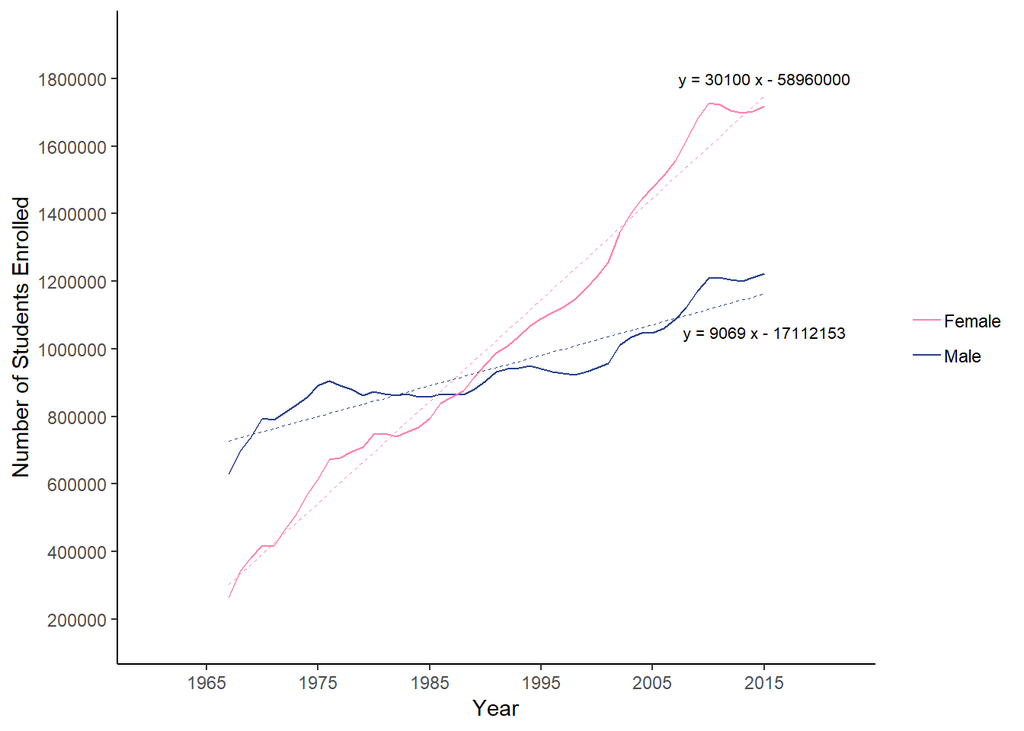

```r
enrollment_trend <- ggplot(grad_enrollment, aes(year)) +
  geom_line(aes(y = total_males, color = "Male"))+
  geom_line(aes(y = total_females, color = "Female")) +
  geom_smooth(aes(x = year, y = total_males, col = "Male"), method = lm, se = F, linetype = "dashed", size = 0.3) +
  geom_smooth(aes(x = year, y = total_females, col = "Female"), method = lm, se = F, linetype = "dashed", size = 0.3) +
  labs(x = "Year", y = "Number of Students Enrolled") +
  theme_classic() +
  theme(plot.caption=element_text(size=8, hjust=0, margin=margin(t=15)), text = element_text(size=11),  legend.title=element_blank()) +
  scale_x_continuous(expand = c(0,10), breaks = c(1955, 1965, 1975, 1985, 1995, 2005, 2015)) +
  scale_y_continuous(expand = c(0, 200000), breaks = c(200000, 400000, 600000, 800000, 1000000, 1200000, 1400000, 1600000, 1800000)) +
  scale_color_manual(values=c("palevioletred1", "royalblue4")) +
  annotate("text", label= "y = 9069 x - 17112153", x=2015, y=1050000, size= 2.8) +
  annotate("text", label= "y = 30100 x - 58960000", x=2015, y=1800000, size= 2.8)


enrollment_trend
```

```r
# Statistical evidence with linear regression

males_lm <- lm(total_males ~ year, data = grad_enrollment)
summary(males_lm)
```

```
##
## Call:
## lm(formula = total_males ~ year, data = grad_enrollment)
##
## Residuals:
##    Min     1Q Median     3Q    Max
## -96461 -34861 -12841  51876  95766
##
## Coefficients:
##              Estimate Std. Error t value Pr(>|t|)
## (Intercept) -17112153    1087024  -15.74   <2e-16 ***
## year             9069        546   16.61   <2e-16 ***
## ---
## Signif. codes:  0 '***' 0.001 '**' 0.01 '*' 0.05 '.' 0.1 ' ' 1
##
## Residual standard error: 54050 on 47 degrees of freedom
## Multiple R-squared:  0.8545, Adjusted R-squared:  0.8514
## F-statistic:   276 on 1 and 47 DF,  p-value: < 2.2e-16
```

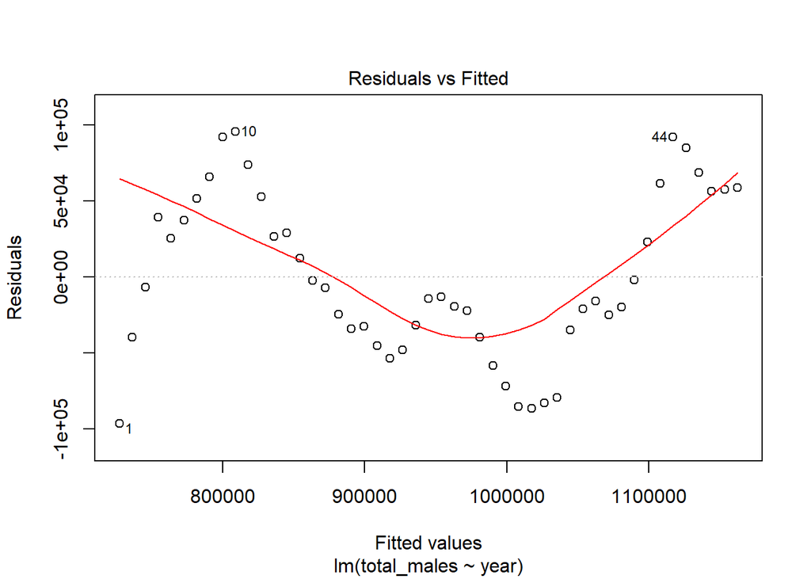

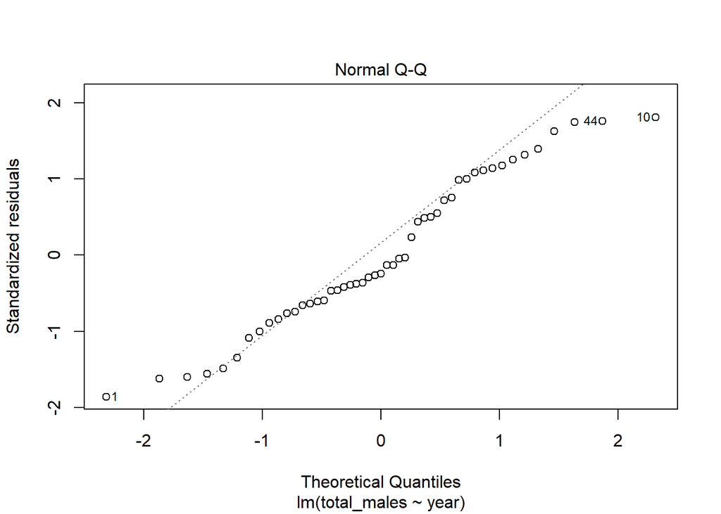

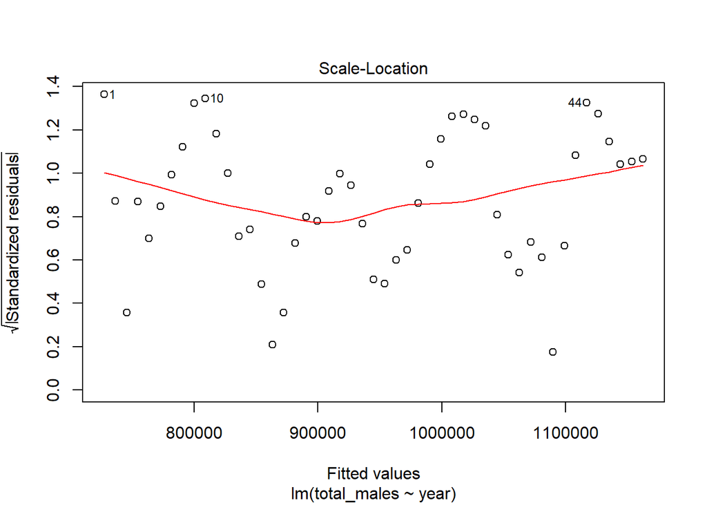

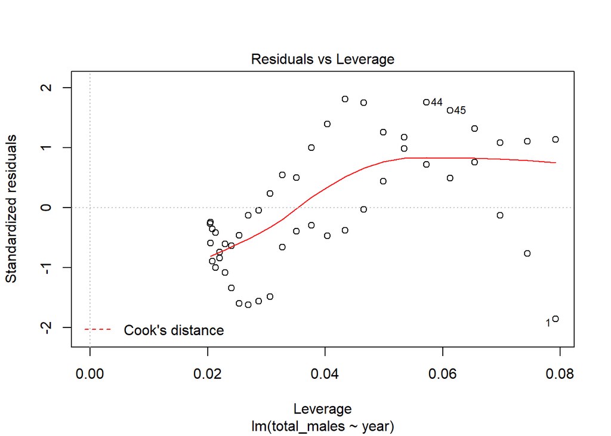

```r
females_lm <- lm(total_females ~ year, data = grad_enrollment)
plot(males_lm)
```

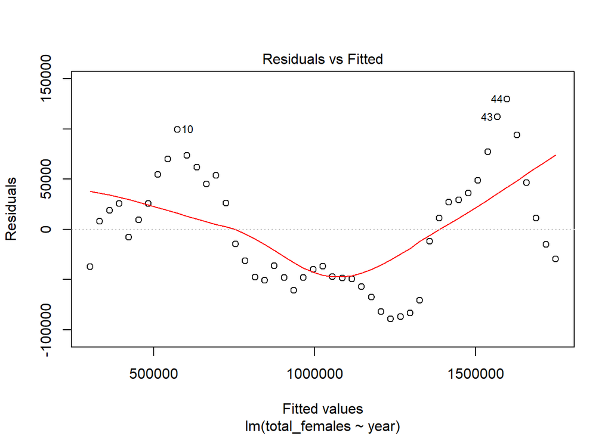

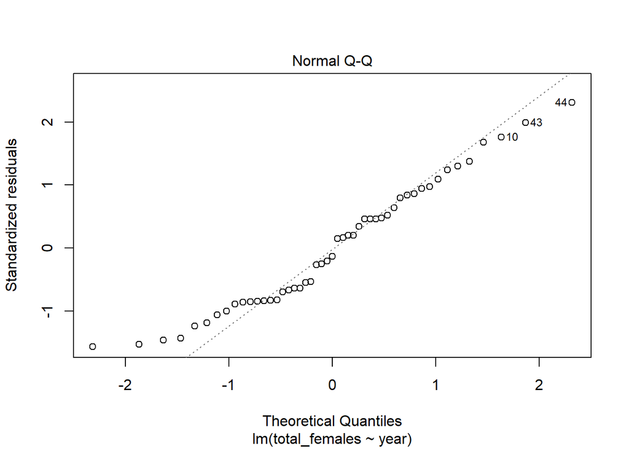

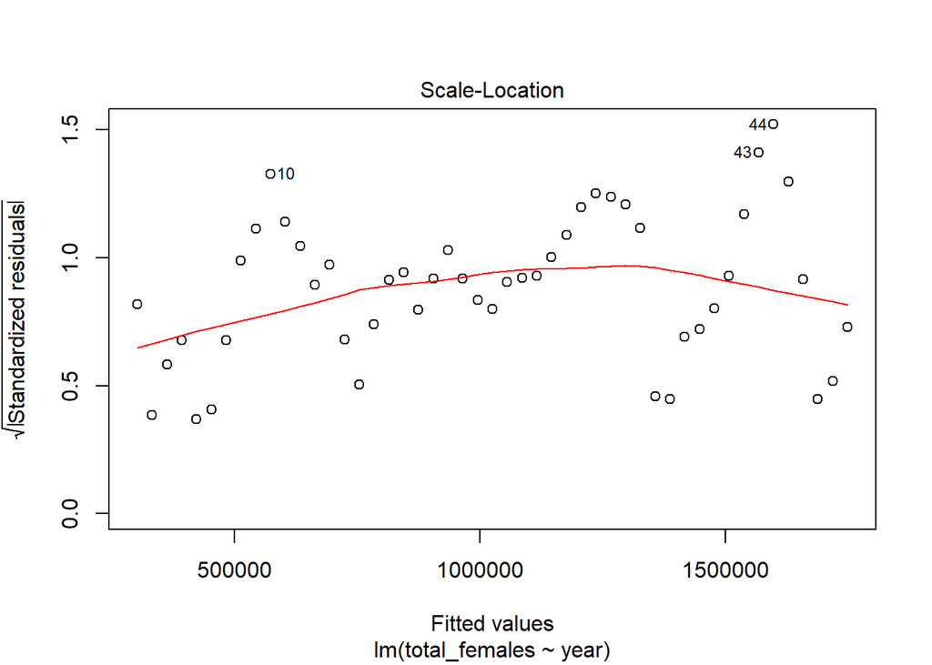

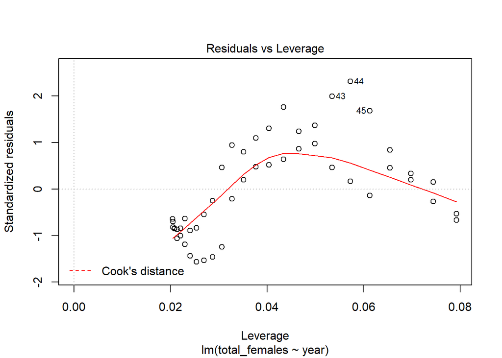

```r
plot(females_lm)
```

```r
summary(females_lm)
```

```
##
## Call:
## lm(formula = total_females ~ year, data = grad_enrollment)
##
## Residuals:
##    Min     1Q Median     3Q    Max
## -89397 -48101  -7633  45267 129727
##
## Coefficients:
##               Estimate Std. Error t value Pr(>|t|)
## (Intercept) -5.896e+07  1.161e+06  -50.77   <2e-16 ***
## year         3.013e+04  5.832e+02   51.66   <2e-16 ***
## ---
## Signif. codes:  0 '***' 0.001 '**' 0.01 '*' 0.05 '.' 0.1 ' ' 1
##
## Residual standard error: 57730 on 47 degrees of freedom
## Multiple R-squared:  0.9827, Adjusted R-squared:  0.9823
## F-statistic:  2669 on 1 and 47 DF,  p-value: < 2.2e-16
```

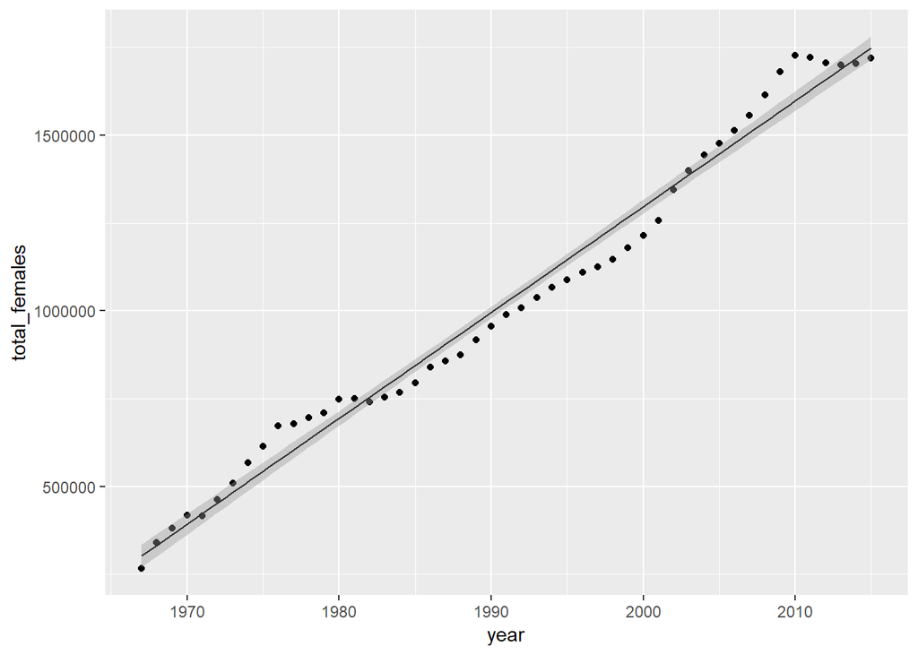

```r
regress_male <- ggplot(grad_enrollment, aes(x=year, y= total_males)) +
  geom_point()+
  geom_smooth(method= lm, se= TRUE, size= 0.5, color="gray20")

regress_female <- ggplot(grad_enrollment, aes(x=year, y= total_females)) +
  geom_point()+
  geom_smooth(method= lm, se= TRUE, size= 0.5, color="gray20")

regress_female
```

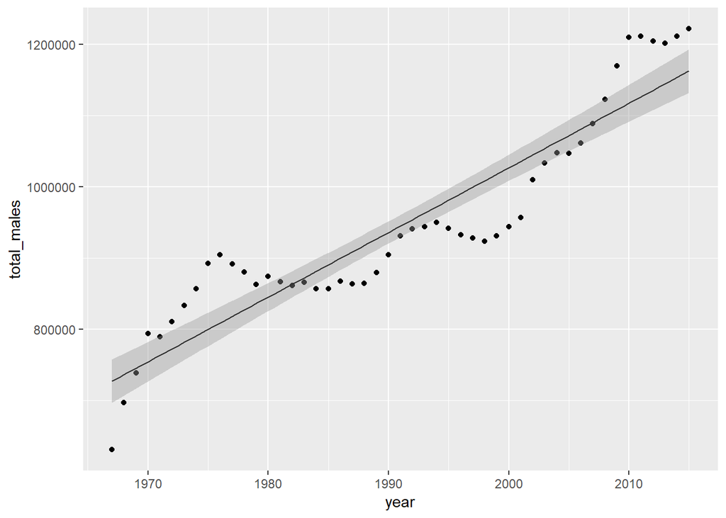

```r
regress_male
```

```r
#and then pearson's r

pearson_females <- cor.test(grad_enrollment$year, grad_enrollment$total_females)
pearson_females
```

```
##
##  Pearson's product-moment correlation
##
## data:  grad_enrollment$year and grad_enrollment$total_females
## t = 51.659, df = 47, p-value < 2.2e-16
## alternative hypothesis: true correlation is not equal to 0
## 95 percent confidence interval:
##  0.9845609 0.9951144
## sample estimates:
##       cor
## 0.9913086
```

```r
# pearson's r = 0.9913086

pearson_males <- cor.test(grad_enrollment$year, grad_enrollment$total_males)
pearson_males
```

```
##
##  Pearson's product-moment correlation
##
## data:  grad_enrollment$year and grad_enrollment$total_males
## t = 16.612, df = 47, p-value < 2.2e-16
## alternative hypothesis: true correlation is not equal to 0
## 95 percent confidence interval:
##  0.8690777 0.9568547
## sample estimates:
##       cor
## 0.9243741
```

```r
# pearson's r = 0.9243741
```

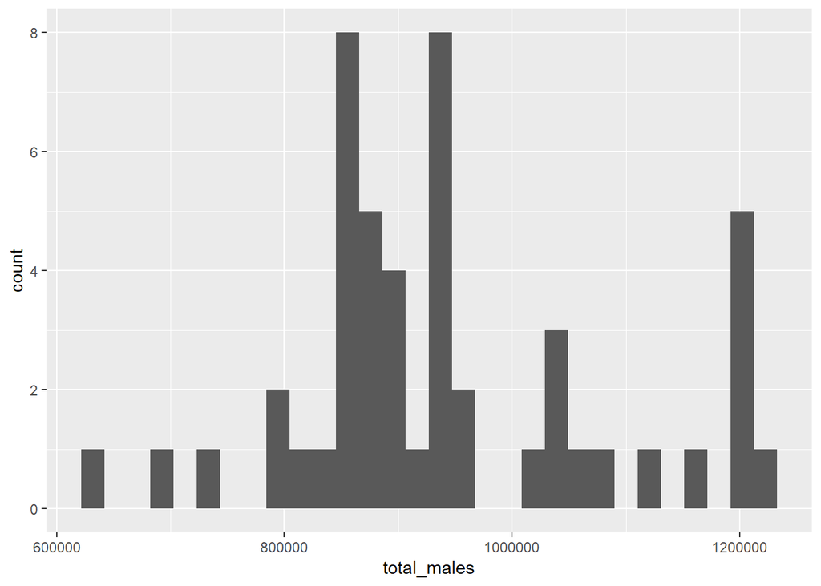

```r
# checking for normality
hist_male_enrol<-ggplot(grad_enrollment, aes(x=total_males)) +
  geom_histogram()

hist_male_enrol
```

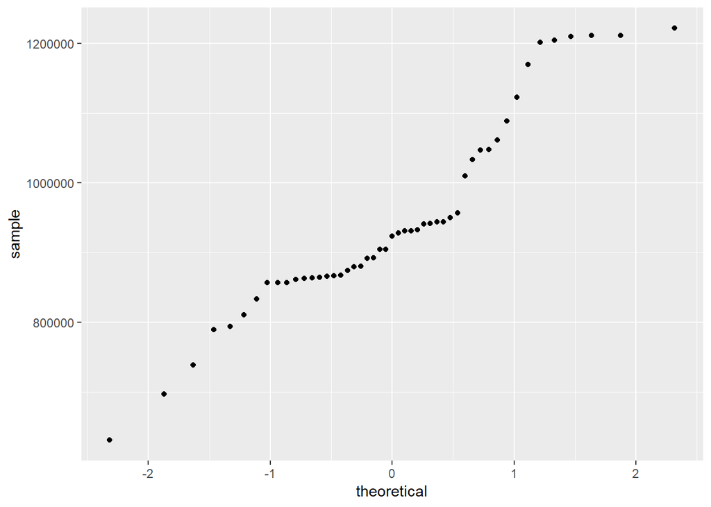

```r
qq_male_enrol <- ggplot(grad_enrollment, aes(sample=total_males)) +
  geom_qq()

qq_male_enrol
```

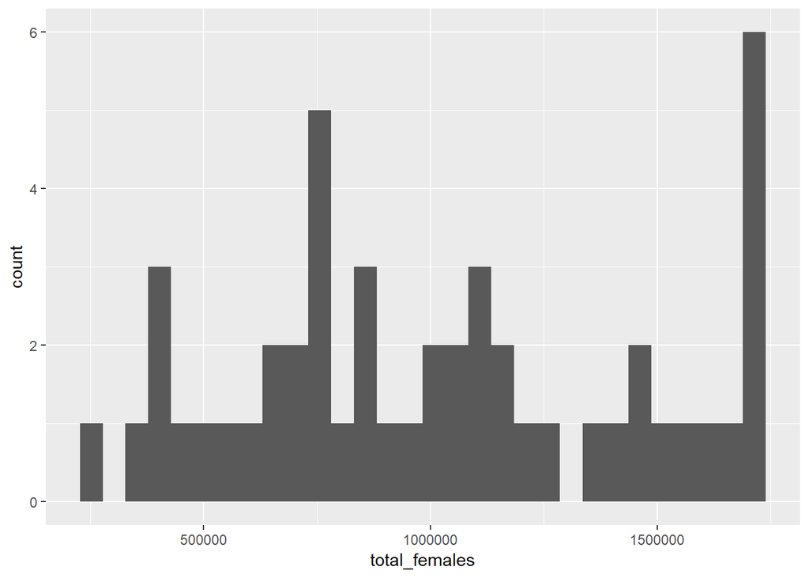

```r
hist_female_enrol <- ggplot(grad_enrollment, aes(x=total_females)) +
  geom_histogram()

qq_female_enrol <- ggplot(grad_enrollment, aes(sample=total_females)) +
  geom_qq()

hist_female_enrol
```

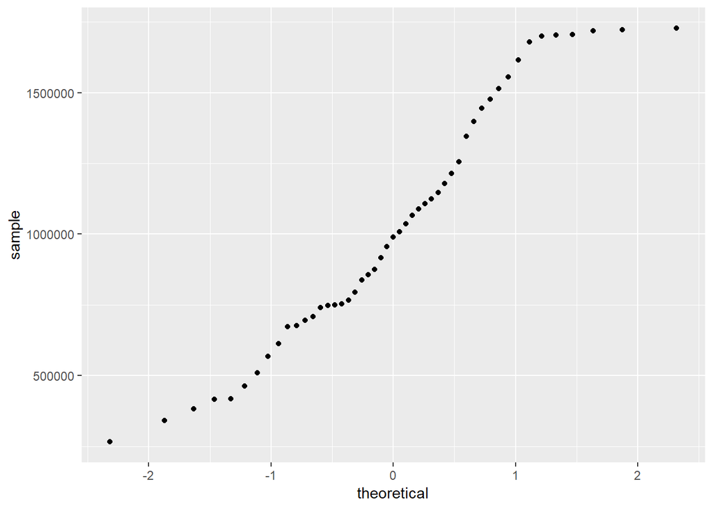

```r
qq_female_enrol
```

Part 2. Describe if and how there was a shift in PhDs awarded to females in four fields (Physical and Earth Sciences, Engineering, Education, and Humanities & Arts) in 1985, 2000, and 2015.

```r
phd<- phd_by_field %>%
  select(field_of_study,`1985_number`, `2000_number`, `2015_number` ) %>%
  filter(field_of_study == "physical_earth_science_female" | field_of_study =="engineering_female" | field_of_study == "education_female" | field_of_study == "humanities_female")

degree <- read_csv("phd_fields.csv")
```

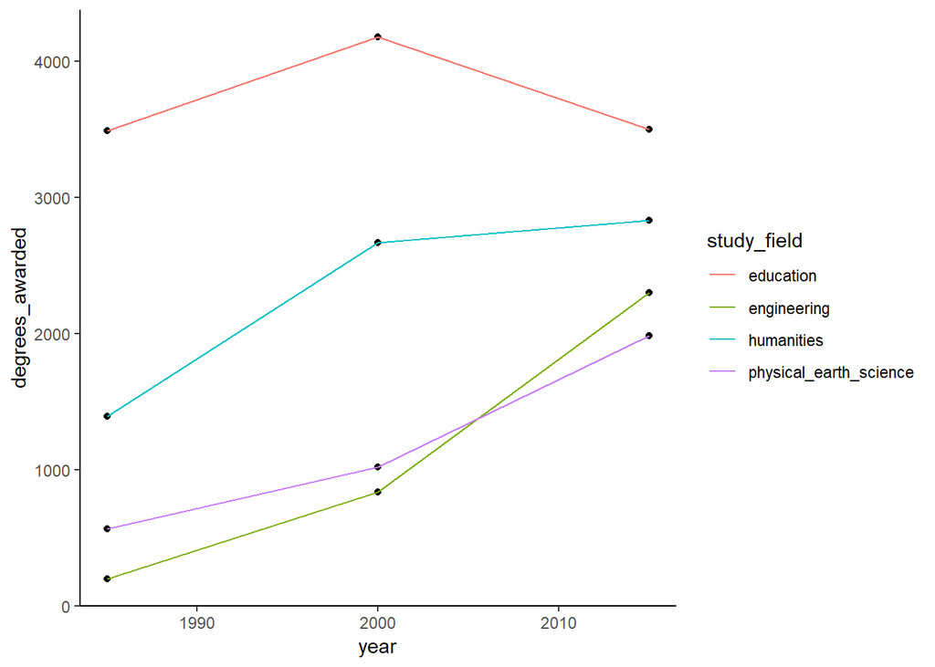

```r
tidy_degree <- as.data.frame(degree) %>%
  expand.dft(freq="degrees_awarded")



deg_graph <- ggplot(degree, aes(x=year, y=degrees_awarded)) +
  geom_point() +
  geom_line(aes(color=study_field)) +
  theme_classic()


deg_graph
```

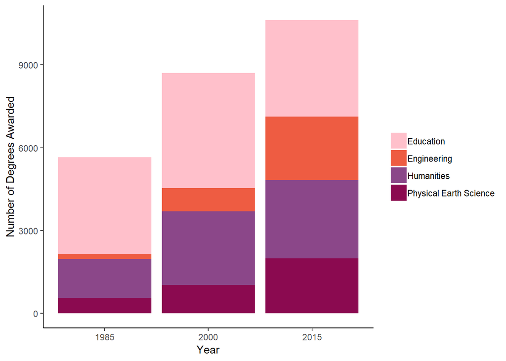

```r
hist_awarded <-ggplot(degree, aes(x=year, y=degrees_awarded))+
  geom_col(aes(fill=study_field)) +
  theme_classic() +
  scale_x_continuous(breaks= seq(1985,2015, by= 15))+
  labs(x= "Year", y="Number of Degrees Awarded") +

  scale_fill_manual(labels= c("Education", "Engineering", "Humanities", "Physical Earth Science"), values= c("pink", "tomato2", "orchid4", "deeppink4")) +
  theme(legend.title = element_blank())



hist_awarded # this is probably pointless
```

```r
#idea: do table chi square to see if year has significant effect on degrees awarded

chi_phd_data <- read_csv("chi_sq_data.csv") %>%
  select(education, engineering, humanities, physical_earth_science)
rownames(chi_phd_data)<- c ("1985", "2000", "2015")
phd_prop <- prop.table(as.matrix(chi_phd_data), 1)

chi_test <- chisq.test(chi_phd_data)
chi_test
```

```
##
##  Pearson's Chi-squared test
##
## data:  chi_phd_data
## X-squared = 2073.4, df = 6, p-value < 2.2e-16
```

```r
phd_prop #it's counting years in so it's off, which makes me think maybe the chi square is off too, so I will try and put in yr:1985 in each to make it a character string and hopefully that will work better.
```

```
##      education engineering humanities physical_earth_science
## 1985 0.6178761  0.03504425  0.2463717              0.1007080
## 2000 0.4797383  0.09620021  0.3067386              0.1173229
## 2015 0.3296931  0.21662587  0.2665223              0.1871587
```

Part 3. Compare median salaries for male and female doctorate recipients in 2015. Answer these two questions: Does median salary differ significantly between male and female starting postdoc positions? Does median salary differ significantly between male and female PhD recipients in non-postdoc employent positions?

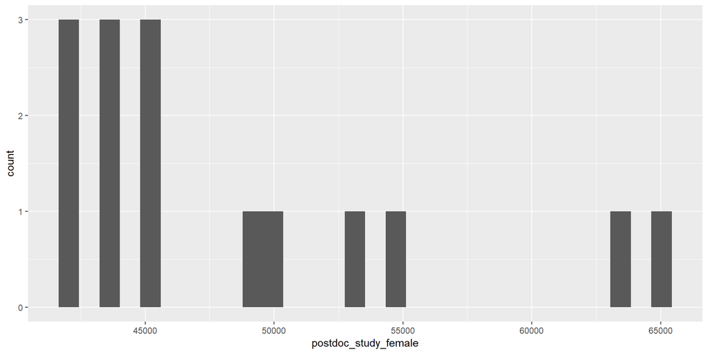

```r
postdoc_female_hist <- ggplot(med_salary, aes(x = postdoc_study_female)) +
  geom_histogram()

postdoc_female_hist
```

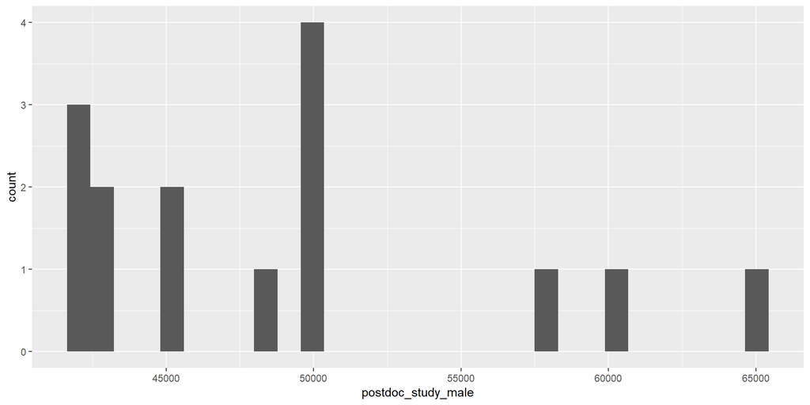

```r
postdoc_male_hist <- ggplot(med_salary, aes(x = postdoc_study_male)) +
  geom_histogram()

postdoc_male_hist
```

```r
mwu_salary <- med_salary %>%
  wilcox.test(med_salary$postdoc_study_male, med_salary$postdoc_study_female, paired = TRUE, data = .)
mwu_salary
```

```
##
##  Wilcoxon signed rank test with continuity correction
##
## data:  med_salary$postdoc_study_male and med_salary$postdoc_study_female
## V = 19.5, p-value = 0.8884
## alternative hypothesis: true location shift is not equal to 0
```

```r
# there is not a significant difference in median salaries for postdoc males and females p = 0.8884, (V = 19.5, p = 0.89)

# Find effect size using cliff's delta
salary_cliff <- cliff.delta(med_salary$postdoc_study_male, med_salary$postdoc_study_female)
salary_cliff
```

```
##
## Cliff's Delta
##
## delta estimate: 0.04 (negligible)
## 95 percent confidence interval:
##        inf        sup
## -0.3710946  0.4379849
```

```r
# cliff's delta = 0.04 (negligible) for median salaries for postdoc males and females

mwu_salary_employment <- med_salary %>%
  wilcox.test(med_salary$employment_male, med_salary$employment_female, paired = TRUE, data = .)
mwu_salary_employment
```

```
##
##  Wilcoxon signed rank test with continuity correction
##
## data:  med_salary$employment_male and med_salary$employment_female
## V = 101, p-value = 0.002572
## alternative hypothesis: true location shift is not equal to 0
```

```r
# there is a significant difference in median salaries for non-postdoc employment for males and females p = 0.002572, (V = 101, p = 0.003)

# Find effect size using cliff's delta
employment_cliff <- cliff.delta(med_salary$employment_male, med_salary$employment_female)
employment_cliff
```

```
##
## Cliff's Delta
##
## delta estimate: 0.2133333 (small)
## 95 percent confidence interval:
##        inf        sup
## -0.2155378  0.5732121
```

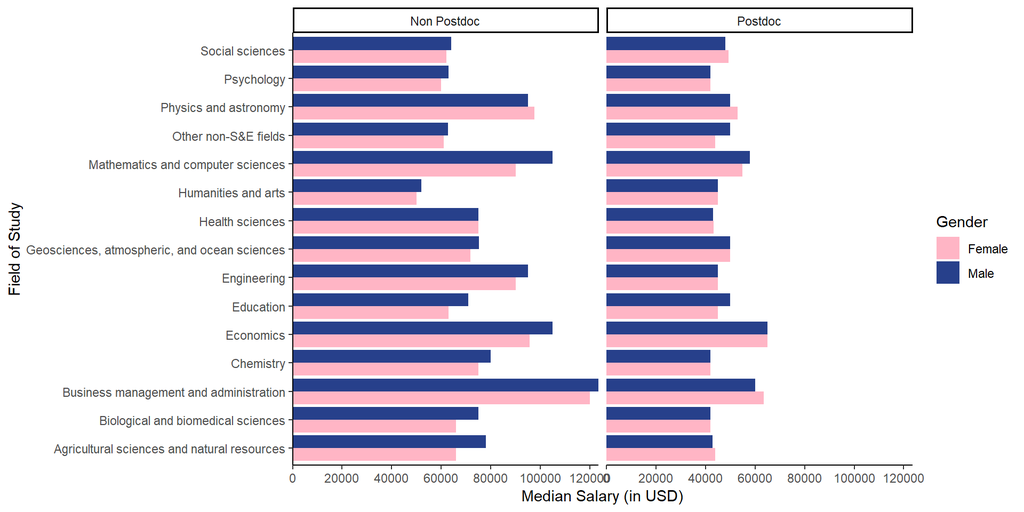

```r
# cliff's delta = 0.213 (small)

med_data_4graph <- gather(med_salary, status, Salary, employment_male, employment_female, postdoc_study_male, postdoc_study_female) %>%
  mutate (
    Gender= case_when(
      status == "employment_male" ~ "Male",
      status == "postdoc_study_male" ~ "Male",
      status == "employment_female" ~ "Female",
      status == "postdoc_study_female" ~ "Female")) %>%
  mutate(
    Status= case_when(
      status == "employment_male" ~ "Non Postdoc",
      status == "postdoc_study_male" ~ "Postdoc",
      status == "employment_female" ~ "Non Postdoc",
      status == "postdoc_study_female" ~ "Postdoc")) %>%
  select(field_of_study, Status, Gender, Salary)

med_graph <- ggplot(med_data_4graph, aes(x= field_of_study, y= Salary)) +
  geom_col(aes(fill=Gender), position="dodge") +
  coord_flip() +
  labs(x= "Field of Study", y= "Median Salary (in USD)") +
  facet_wrap(~ Status)+
  scale_y_continuous(breaks= seq(0,125000, by= 20000), expand= c(0,0))+
  theme_classic() +
  scale_fill_manual(values = c("pink1", "royalblue4"))

med_graph
```

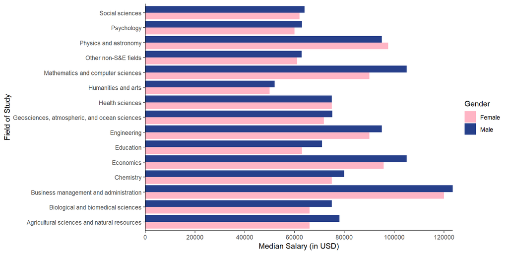

```r
med_graph_2 <- med_data_4graph %>%
  filter(Status == "Non Postdoc") %>%
  ggplot(aes(x= field_of_study, y= Salary)) +
  geom_col(aes(fill=Gender), position="dodge") +
  coord_flip() +
  labs(x= "Field of Study", y= "Median Salary (in USD)") +
  scale_y_continuous(breaks= seq(0,125000, by= 20000), expand= c(0,0)) +
  theme_classic() +
  scale_fill_manual(values = c("pink1", "royalblue4"))

med_graph_2
```

Part 4. Explore relationships between variables in the ‘Faculty salary data (2008-2009)’ dataset (faculty_salary). Develop a model describing faculty salary based on data for faculty sex, rank, years in current position, field, and number of years since doctoral degree was earned. YOU should make decisions regarding which variables should remain in your final model.

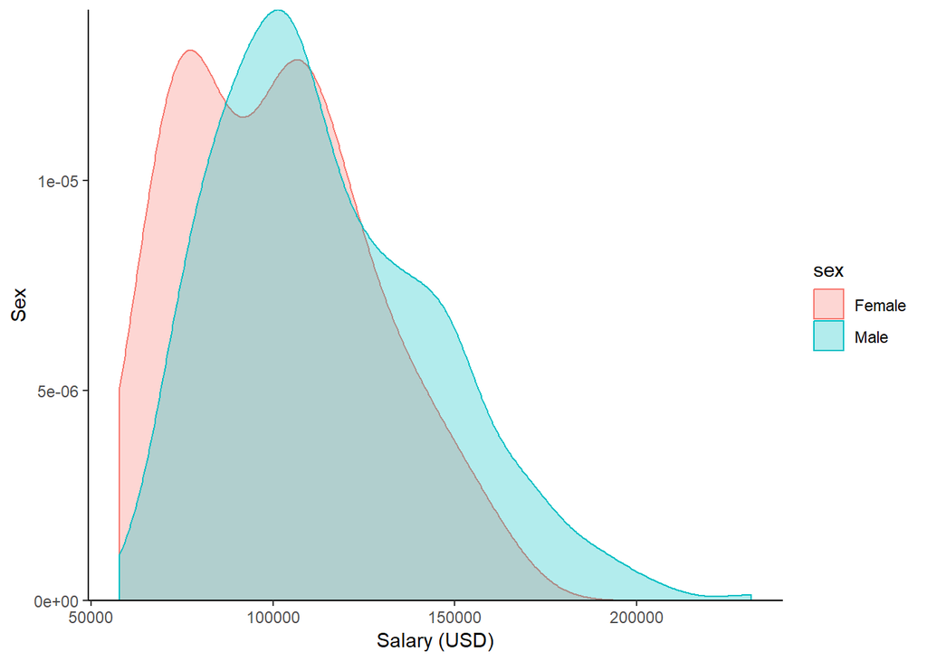

```r
#A. Go exploring (visual) + think critically about variables

#Relationship 1: Explore faculty salary by sex

mean_by_sex <- faculty_salary %>%
  group_by(sex) %>%
  summarize(
    mean = mean(salary)
  )

# b. Visualize salaries by sex
by_sex <- ggplot(faculty_salary, aes(x = salary)) +
  geom_density(aes(color = sex, fill = sex), alpha = 0.3) + # Note: just to show what the geom_violin shows
  theme_classic() +
  scale_y_continuous(expand = c(0,0)) +
  labs(x = "Salary (USD)", y = "Sex")

by_sex
```

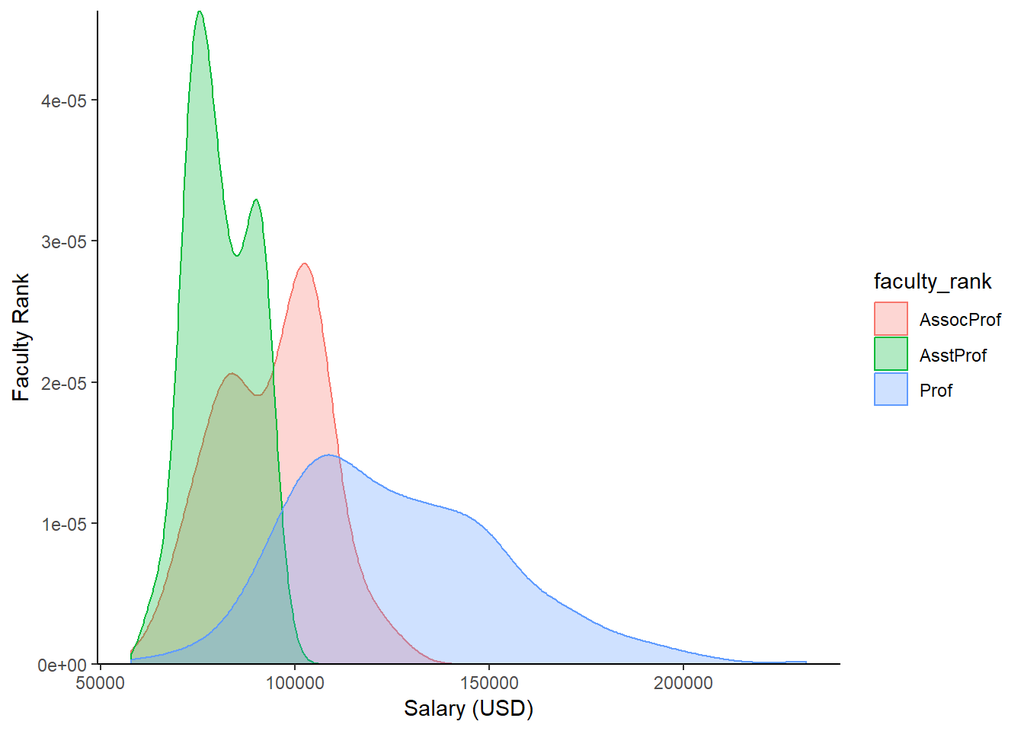

```r
#Relationship 2: Explore faculty salary by rank

mean_by_rank <- faculty_salary %>%
  group_by(faculty_rank) %>%
  summarize(
    mean = mean(salary)
  )

by_rank <- ggplot(faculty_salary, aes(x = salary)) +
  geom_density(aes(color = faculty_rank, fill = faculty_rank), alpha = 0.3) +
  theme_classic() +
  scale_y_continuous(expand = c(0,0)) +
  labs(x = "Salary (USD)", y = "Faculty Rank")

by_rank
```

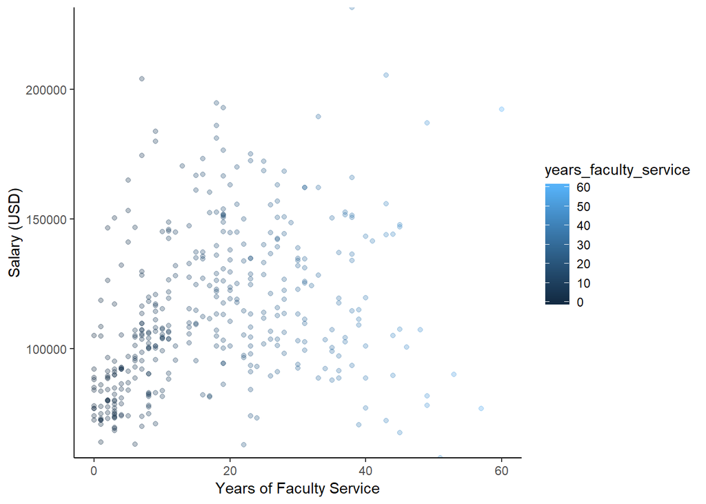

```r
#Relationship 3: Explore faculty salary by years in current position

mean_by_years <- faculty_salary %>%
  group_by(years_faculty_service) %>%
  summarize(
    mean = mean(salary)
  )

by_years <- ggplot(faculty_salary, aes(x = years_faculty_service, y= salary)) +
  geom_point(aes(color = years_faculty_service, fill = years_faculty_service), alpha = 0.3) + #
  theme_classic() +
  scale_y_continuous(expand = c(0,0)) +
  labs(x = "Years of Faculty Service", y = "Salary (USD)")

by_years
```

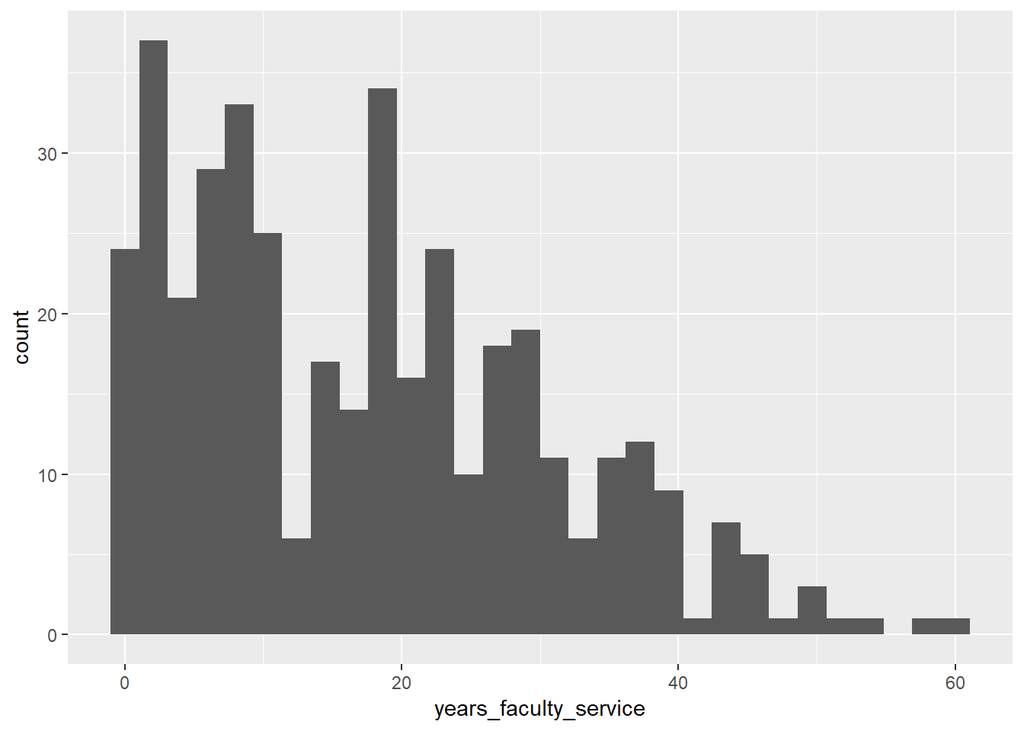

```r
# Make histograms or qqplots instead to assess normality

hist_years_service <- ggplot(faculty_salary, aes(x = years_faculty_service)) +
  geom_histogram()
hist_years_service # does NOT look normally distributed!
```

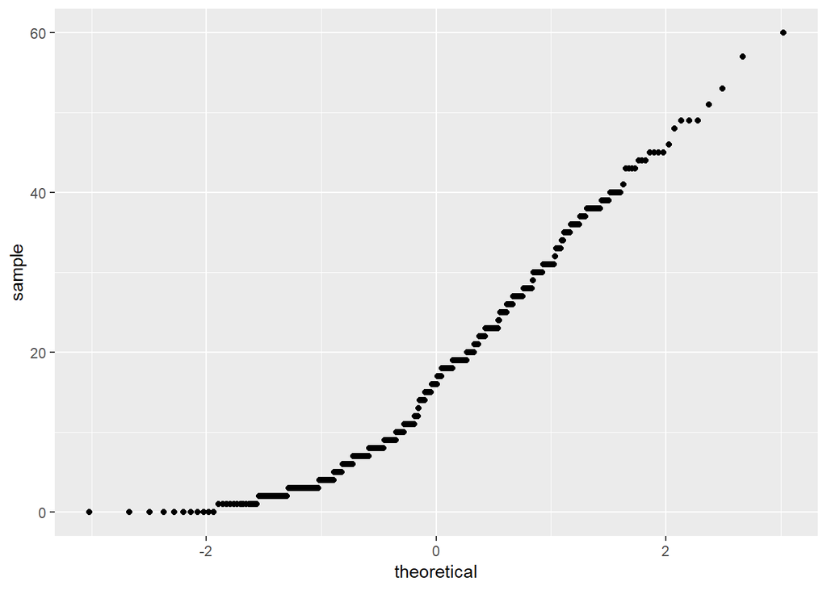

```r
qq_service <- ggplot(faculty_salary, aes(sample=years_faculty_service)) +
  geom_qq()
qq_service # this has kinda an exponential look to it--not normally distributed and dont include in model?!
```

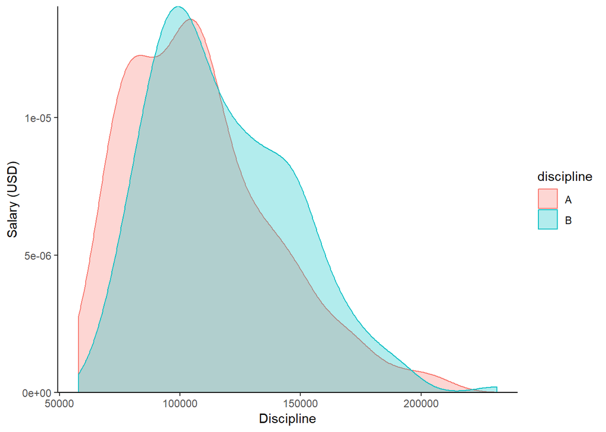

```r
#Relationship 4: Explore faculty salary by field

#??? Note sure about the A/B situation...

mean_by_discip <- faculty_salary %>%
  group_by(discipline) %>%
  summarize(
    mean = mean(salary)
  )

by_discip <- ggplot(faculty_salary, aes(x = salary)) +
  geom_density(aes(color = discipline, fill = discipline), alpha = 0.3) +
  theme_classic() +
  scale_y_continuous(expand = c(0,0)) +
  labs(x = "Discipline", y = "Salary (USD)")

by_discip
```

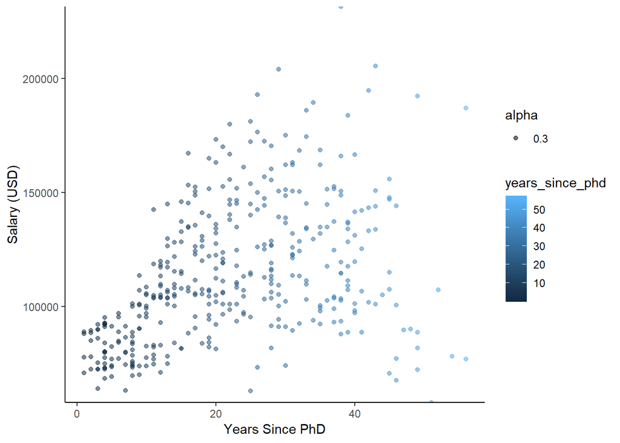

```r
#Relationship 5: Explore faculty salary by # years since PhD

mean_by_phd <- faculty_salary %>%
  group_by(years_since_phd) %>%
  summarize(
    mean = mean(salary)
  )

by_phd <- ggplot(faculty_salary, aes(x = years_since_phd, y= salary)) +
  geom_point(aes(color = years_since_phd, alpha = 0.3)) +
  theme_classic() +
  scale_y_continuous(expand = c(0,0)) +
  labs(x = "Years Since PhD", y = "Salary (USD)")

by_phd
```

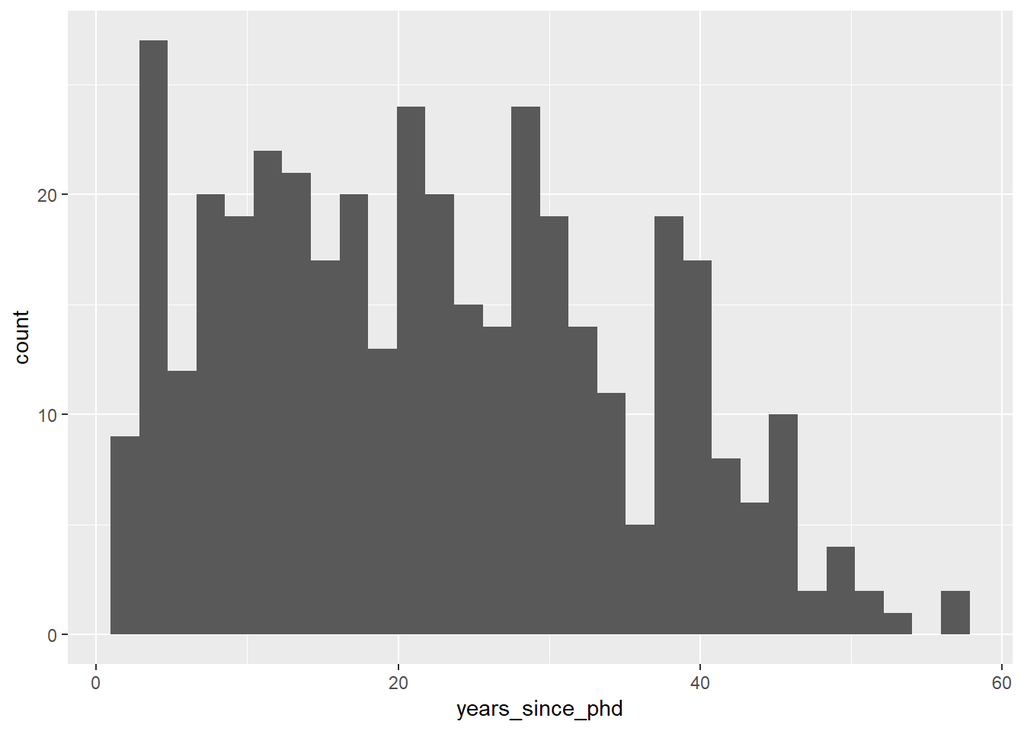

```r
#histogram to assess normality

hist_phd <- ggplot(faculty_salary, aes(x = years_since_phd)) +
  geom_histogram()
hist_phd # this looks a bit more normally distributed than the years of sevice!
```

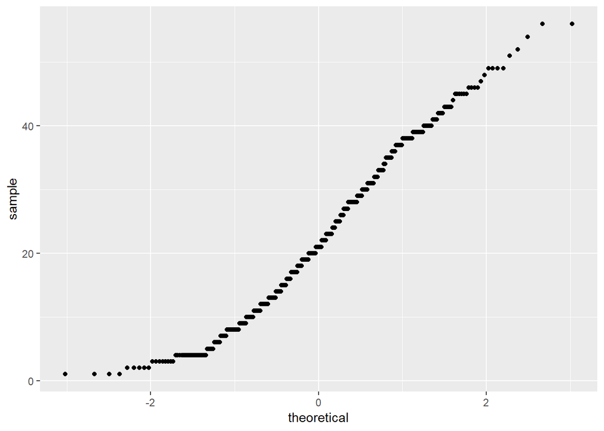

```r
qq_phd <- ggplot(faculty_salary, aes(sample=years_since_phd))+
  geom_qq()
qq_phd #this looks pretty normally distributed!
```

```r
# okay-- I think we need to take out either years since phd or years of service- they are basically the same thing. Which to take out?

# Multi-Linear Regression Model: include rank, years in service, discipline, and sex (4 variables)
salary_lm_all <- lm(salary ~ sex + faculty_rank + years_since_phd + years_faculty_service + discipline, data = faculty_salary)

salary_lm1 <- lm(salary ~ sex + faculty_rank + years_faculty_service + discipline, data = faculty_salary)
salary_lm1
```

Call: lm(formula = salary ~ sex + faculty_rank + years_faculty_service + discipline, data = faculty_salary)

Coefficients: (Intercept) sexMale faculty_rankAsstProf  
82912.07 4771.25 -14560.40  
faculty_rankProf years_faculty_service disciplineB  
34599.24 -88.78 13473.38

```r
#Interpretation: ???????? looking at coeffs for salary and sex,

summary(salary_lm1)
```

Call: lm(formula = salary ~ sex + faculty_rank + years_faculty_service + discipline, data = faculty_salary)